# malicious-urls-detection

## Project overview

The project consisted to evaluate different classification models to predict malicious and benign websites, based on application layer and network characteristics.

## Problem statement

Confidentiality and Privacy is the biggest challenge faced. If a user access the

malicious website through a search engine with no perception, malicious scripts

usually launch attacks to install rogue program, steal personal identities and

credentials, so our Problem is to develop an algorithm which accurately predicts

the malicious and the benign URLs.

This is a binary classification supervised problem that takes the URL as an input and returns

whether it contains malicious content or not as an output.

We've got our dataset from Kaggle platform: https://www.kaggle.com/xwolf12/malicious-and-benign-websites

- 216 malicious URLs (12 %)

in This project I'll evaluate different supervised algorithms to classify the URLs based on this data and the features related to each URL like URL length and the number of special characters in the URL.

## 1- Exploring the Data

### Importing the data and the neccessary libraries

```python
import numpy as np
import pandas as pd
from time import time
from matplotlib import pyplot as plt
from IPython.display import display
import seaborn as sns
%matplotlib inline
```

### Loding the data

```python
data = pd.read_csv("dataset.csv")
display(data)
```

|  | URL | URL_LENGTH | NUMBER_SPECIAL_CHARACTERS | CHARSET | SERVER | CONTENT_LENGTH | WHOIS_COUNTRY | WHOIS_STATEPRO | WHOIS_REGDATE | WHOIS_UPDATED_DATE | ... | DIST_REMOTE_TCP_PORT | REMOTE_IPS | APP_BYTES | SOURCE_APP_PACKETS | REMOTE_APP_PACKETS | SOURCE_APP_BYTES | REMOTE_APP_BYTES | APP_PACKETS | DNS_QUERY_TIMES | Type |
| --- | --- | --- | --- | --- | --- | --- | --- | --- | --- | --- | --- | --- | --- | --- | --- | --- | --- | --- | --- | --- | --- |
| 0 | M0_109 | 16 | 7 | iso-8859-1 | nginx | 263.0 | None | None | 10/10/2015 18:21 | None | ... | 0 | 2 | 700 | 9 | 10 | 1153 | 832 | 9 | 2.0 | 1 |
| 1 | B0_2314 | 16 | 6 | UTF-8 | Apache/2.4.10 | 15087.0 | None | None | None | None | ... | 7 | 4 | 1230 | 17 | 19 | 1265 | 1230 | 17 | 0.0 | 0 |
| 2 | B0_911 | 16 | 6 | us-ascii | Microsoft-HTTPAPI/2.0 | 324.0 | None | None | None | None | ... | 0 | 0 | 0 | 0 | 0 | 0 | 0 | 0 | 0.0 | 0 |
| 3 | B0_113 | 17 | 6 | ISO-8859-1 | nginx | 162.0 | US | AK | 7/10/1997 4:00 | 12/09/2013 0:45 | ... | 22 | 3 | 3812 | 39 | 37 | 18784 | 4380 | 39 | 8.0 | 0 |
| 4 | B0_403 | 17 | 6 | UTF-8 | None | 124140.0 | US | TX | 12/05/1996 0:00 | 11/04/2017 0:00 | ... | 2 | 5 | 4278 | 61 | 62 | 129889 | 4586 | 61 | 4.0 | 0 |
| 5 | B0_2064 | 18 | 7 | UTF-8 | nginx | NaN | SC | Mahe | 3/08/2016 14:30 | 3/10/2016 3:45 | ... | 6 | 9 | 894 | 11 | 13 | 838 | 894 | 11 | 0.0 | 0 |
| 6 | B0_462 | 18 | 6 | iso-8859-1 | Apache/2 | 345.0 | US | CO | 29/07/2002 0:00 | 1/07/2016 0:00 | ... | 0 | 3 | 1189 | 14 | 13 | 8559 | 1327 | 14 | 2.0 | 0 |
| 7 | B0_1128 | 19 | 6 | us-ascii | Microsoft-HTTPAPI/2.0 | 324.0 | US | FL | 18/03/1997 0:00 | 19/03/2017 0:00 | ... | 0 | 0 | 0 | 0 | 0 | 0 | 0 | 0 | 0.0 | 0 |
| 8 | M2_17 | 20 | 5 | utf-8 | nginx/1.10.1 | NaN | None | None | 8/11/2014 7:41 | None | ... | 0 | 0 | 0 | 2 | 3 | 213 | 146 | 2 | 2.0 | 1 |
| 9 | M3_75 | 20 | 5 | utf-8 | nginx/1.10.1 | NaN | None | None | 8/11/2014 7:41 | None | ... | 0 | 0 | 0 | 2 | 1 | 62 | 146 | 2 | 2.0 | 1 |
| 10 | B0_1013 | 20 | 6 | utf-8 | Apache | NaN | US | Kansas | 14/09/2007 0:00 | 9/09/2015 0:00 | ... | 0 | 0 | 0 | 0 | 0 | 0 | 0 | 0 | 0.0 | 0 |
| 11 | B0_1102 | 20 | 6 | us-ascii | Microsoft-HTTPAPI/2.0 | 324.0 | US | CO | 22/11/2016 0:00 | 23/11/2016 0:00 | ... | 0 | 0 | 0 | 0 | 0 | 0 | 0 | 0 | 0.0 | 0 |
| 12 | B0_22 | 20 | 7 | utf-8 | None | 13716.0 | GB | None | 11/10/2002 0:00 | 6/10/2016 0:00 | ... | 6 | 8 | 1492 | 20 | 20 | 2334 | 1784 | 20 | 4.0 | 0 |
| 13 | B0_482 | 20 | 6 | ISO-8859-1 | nginx | 3692.0 | None | None | 14/11/2002 0:00 | 19/04/2015 0:00 | ... | 19 | 4 | 3946 | 35 | 29 | 16408 | 4746 | 35 | 10.0 | 0 |
| 14 | B0_869 | 20 | 7 | ISO-8859-1 | Apache/2.2.15 (Red Hat) | 13054.0 | None | None | None | None | ... | 0 | 0 | 0 | 0 | 0 | 0 | 0 | 0 | 0.0 | 0 |
| 15 | M0_71 | 21 | 7 | ISO-8859-1 | Apache/2.4.23 (Unix) OpenSSL/1.0.1e-fips mod_b... | 957.0 | UK | None | 16/07/2000 0:00 | 4/07/2015 0:00 | ... | 0 | 1 | 717 | 11 | 10 | 1960 | 1011 | 11 | 4.0 | 1 |
| 16 | M0_97 | 21 | 7 | iso-8859-1 | nginx | 686.0 | RU | Novosibirskaya obl. | 25/05/2013 0:00 | 23/05/2016 0:00 | ... | 0 | 2 | 603 | 8 | 9 | 1580 | 745 | 8 | 2.0 | 1 |
| 17 | B0_2303 | 21 | 6 | us-ascii | Microsoft-HTTPAPI/2.0 | 324.0 | None | None | 9/08/1999 0:00 | 10/02/2015 0:00 | ... | 7 | 3 | 618 | 7 | 9 | 562 | 618 | 7 | 0.0 | 0 |
| 18 | B0_584 | 21 | 6 | utf-8 | nginx | 15025.0 | None | None | None | None | ... | 1 | 5 | 1099 | 15 | 17 | 15476 | 1243 | 15 | 2.0 | 0 |
| 19 | M0_69 | 22 | 7 | us-ascii | Microsoft-HTTPAPI/2.0 | 324.0 | US | CO | 15/09/2013 0:00 | 25/02/2017 0:00 | ... | 0 | 4 | 850 | 11 | 9 | 1354 | 994 | 11 | 2.0 | 1 |
| 20 | B0_161 | 22 | 6 | utf-8 | openresty/1.11.2.1 | NaN | US | CA | 3/07/1999 0:00 | 7/08/2015 0:00 | ... | 29 | 6 | 3833 | 43 | 42 | 22495 | 4125 | 43 | 4.0 | 0 |
| 21 | B0_2122 | 22 | 6 | iso-8859-1 | nginx | 318.0 | US | Tennessee | 2/11/2003 0:00 | 29/06/2015 0:00 | ... | 6 | 6 | 696 | 8 | 10 | 636 | 696 | 8 | 0.0 | 0 |
| 22 | B0_2176 | 22 | 6 | iso-8859-1 | Apache/2.2.22 | 224.0 | None | None | 12/08/2008 22:10 | 13/07/2016 17:36 | ... | 3 | 2 | 420 | 4 | 6 | 372 | 420 | 4 | 0.0 | 0 |
| 23 | B0_569 | 22 | 7 | utf-8 | Apache/2.4.7 (Ubuntu) | 4421.0 | AU | Vi | 21/05/2009 0:00 | 15/05/2016 0:00 | ... | 0 | 2 | 2259 | 16 | 12 | 5165 | 2559 | 16 | 4.0 | 0 |
| 24 | B0_601 | 22 | 6 | UTF-8 | nginx/1.12.0 | NaN | US | FL | 1/08/2002 0:00 | 22/03/2016 0:00 | ... | 0 | 3 | 650 | 10 | 10 | 1417 | 950 | 10 | 4.0 | 0 |
| 25 | B0_884 | 22 | 6 | ISO-8859-1 | Apache | 441.0 | US | OR | 13/01/2005 0:00 | 2/03/2017 0:00 | ... | 0 | 0 | 0 | 0 | 0 | 0 | 0 | 0 | 0.0 | 0 |
| 26 | B0_905 | 22 | 6 | ISO-8859-1 | nginx/1.12.0 | NaN | US | Texas | 18/05/2005 19:41 | 19/05/2016 10:14 | ... | 0 | 0 | 0 | 0 | 0 | 0 | 0 | 0 | 0.0 | 0 |
| 27 | B0_916 | 22 | 6 | utf-8 | nginx | 6671.0 | CA | ALBERTA | 4/01/2001 0:00 | 3/03/2017 0:00 | ... | 0 | 0 | 0 | 0 | 0 | 0 | 0 | 0 | 0.0 | 0 |
| 28 | B0_102 | 23 | 6 | utf-8 | Apache | NaN | US | FL | 28/02/2008 10:58 | 14/02/2017 20:27 | ... | 3 | 11 | 1696 | 18 | 20 | 13422 | 1844 | 18 | 2.0 | 0 |
| 29 | B0_1130 | 23 | 6 | iso-8859-1 | Apache/2.4.12 (Unix) OpenSSL/1.0.1e-fips mod_b... | 434.0 | PA | PANAMA | 8/12/2006 0:00 | 14/12/2015 0:00 | ... | 0 | 0 | 0 | 0 | 0 | 0 | 0 | 0 | 0.0 | 0 |
| ... | ... | ... | ... | ... | ... | ... | ... | ... | ... | ... | ... | ... | ... | ... | ... | ... | ... | ... | ... | ... | ... |
| 1751 | B0_531 | 142 | 22 | ISO-8859-1 | Apache/2.2.15 (CentOS) DAV/2 mod_ssl/2.2.15 Op... | 3929.0 | US | IL | 27/07/1995 0:00 | 8/06/2015 0:00 | ... | 2 | 6 | 5398 | 74 | 68 | 137144 | 5740 | 74 | 4.0 | 0 |
| 1752 | M4_32 | 143 | 26 | UTF-8 | Apache | NaN | ES | Barcelona | 17/09/2008 0:00 | 2/09/2016 0:00 | ... | 0 | 0 | 0 | 0 | 2 | 124 | 0 | 0 | 0.0 | 1 |
| 1753 | M4_47 | 143 | 27 | UTF-8 | Apache | NaN | ES | Barcelona | 17/09/2008 0:00 | 2/09/2016 0:00 | ... | 0 | 0 | 0 | 0 | 2 | 124 | 0 | 0 | 0.0 | 1 |
| 1754 | B0_2233 | 143 | 22 | ISO-8859-1 | AkamaiGHost | 374.0 | US | DC | 15/06/2006 0:00 | 22/06/2016 0:00 | ... | 5 | 2 | 564 | 6 | 7 | 442 | 564 | 6 | 0.0 | 0 |
| 1755 | B0_412 | 144 | 21 | utf-8 | Apache | 14060.0 | None | None | 27/09/2000 0:00 | 26/07/2016 0:00 | ... | 0 | 4 | 2854 | 25 | 17 | 3490 | 3146 | 25 | 4.0 | 0 |
| 1756 | M4_28 | 145 | 26 | UTF-8 | Apache | NaN | ES | Barcelona | 17/09/2008 0:00 | 2/09/2016 0:00 | ... | 0 | 0 | 0 | 0 | 2 | 124 | 0 | 0 | 0.0 | 1 |
| 1757 | M4_40 | 145 | 27 | UTF-8 | Apache | NaN | ES | Barcelona | 17/09/2008 0:00 | 2/09/2016 0:00 | ... | 0 | 0 | 0 | 0 | 3 | 186 | 0 | 0 | 0.0 | 1 |
| 1758 | M4_56 | 145 | 29 | UTF-8 | Apache | NaN | ES | Barcelona | 17/09/2008 0:00 | 2/09/2016 0:00 | ... | 0 | 0 | 0 | 0 | 2 | 124 | 0 | 0 | 0.0 | 1 |
| 1759 | B0_216 | 145 | 31 | UTF-8 | None | 38361.0 | US | NY | 10/08/1995 0:00 | 5/08/2016 0:00 | ... | 3 | 3 | 1354 | 18 | 19 | 2517 | 2010 | 18 | 8.0 | 0 |
| 1760 | M4_49 | 146 | 27 | UTF-8 | Apache | NaN | ES | Barcelona | 17/09/2008 0:00 | 2/09/2016 0:00 | ... | 0 | 0 | 0 | 0 | 3 | 186 | 0 | 0 | 0.0 | 1 |
| 1761 | M4_57 | 146 | 28 | UTF-8 | Apache | NaN | ES | Barcelona | 17/09/2008 0:00 | 2/09/2016 0:00 | ... | 0 | 0 | 0 | 0 | 2 | 124 | 0 | 0 | 0.0 | 1 |
| 1762 | B0_221 | 146 | 24 | UTF-8 | nginx | 11833.0 | US | Arizona | 13/07/1998 0:00 | 28/03/2017 0:00 | ... | 20 | 8 | 4167 | 33 | 33 | 3181 | 4499 | 33 | 4.0 | 0 |
| 1763 | B0_1361 | 149 | 23 | ISO-8859-1 | None | 6748.0 | CA | Quebec | 8/01/1997 0:00 | 2/06/2009 0:00 | ... | 0 | 0 | 0 | 0 | 0 | 0 | 0 | 0 | 0.0 | 0 |
| 1764 | M4_35 | 150 | 26 | UTF-8 | Apache | NaN | ES | Barcelona | 17/09/2008 0:00 | 2/09/2016 0:00 | ... | 0 | 0 | 0 | 0 | 3 | 186 | 0 | 0 | 0.0 | 1 |
| 1765 | M4_54 | 151 | 29 | UTF-8 | Apache | NaN | ES | Barcelona | 17/09/2008 0:00 | 2/09/2016 0:00 | ... | 0 | 0 | 0 | 0 | 3 | 186 | 0 | 0 | 0.0 | 1 |
| 1766 | B0_755 | 154 | 21 | UTF-8 | None | 11104.0 | US | UT | 29/07/1998 4:00 | 17/03/2016 4:34 | ... | 10 | 8 | 3764 | 41 | 23 | 7356 | 4412 | 41 | 8.0 | 0 |
| 1767 | M4_62 | 156 | 31 | UTF-8 | Apache | NaN | ES | Barcelona | 17/09/2008 0:00 | 2/09/2016 0:00 | ... | 1 | 1 | 90 | 1 | 5 | 416 | 90 | 1 | 0.0 | 1 |
| 1768 | B0_62 | 160 | 29 | UTF-8 | None | 36829.0 | US | CA | 14/08/1997 0:00 | 14/06/2016 0:00 | ... | 3 | 7 | 2402 | 25 | 22 | 4491 | 2900 | 25 | 6.0 | 0 |
| 1769 | B0_2237 | 161 | 23 | iso-8859-1 | Apache/2.4.18 (Ubuntu) | 417.0 | None | None | 23/11/2010 0:00 | 20/11/2015 0:00 | ... | 7 | 2 | 582 | 7 | 11 | 752 | 582 | 7 | 0.0 | 0 |
| 1770 | B0_2099 | 169 | 25 | utf-8 | cloudflare-nginx | NaN | BS | New Providence | 20/12/2008 0:00 | 11/12/2015 0:00 | ... | 3 | 4 | 552 | 6 | 9 | 564 | 552 | 6 | 0.0 | 0 |
| 1771 | M4_43 | 170 | 17 | UTF-8 | Apache | NaN | ES | Barcelona | 17/09/2008 0:00 | 2/09/2016 0:00 | ... | 0 | 0 | 0 | 0 | 2 | 124 | 0 | 0 | 0.0 | 1 |
| 1772 | M4_61 | 173 | 34 | UTF-8 | Apache | NaN | ES | Barcelona | 17/09/2008 0:00 | 2/09/2016 0:00 | ... | 1 | 1 | 90 | 1 | 5 | 416 | 90 | 1 | 0.0 | 1 |
| 1773 | M4_39 | 178 | 16 | UTF-8 | Apache | NaN | ES | Barcelona | 17/09/2008 0:00 | 2/09/2016 0:00 | ... | 0 | 0 | 0 | 0 | 3 | 186 | 0 | 0 | 0.0 | 1 |
| 1774 | B0_156 | 183 | 29 | ISO-8859-1 | Microsoft-IIS/7.5; litigation_essentials.lexis... | 4890.0 | US | NY | 26/06/1997 0:00 | 18/11/2014 0:00 | ... | 2 | 7 | 2062 | 30 | 26 | 8161 | 2742 | 30 | 8.0 | 0 |
| 1775 | M4_45 | 194 | 17 | UTF-8 | Apache | NaN | ES | Barcelona | 17/09/2008 0:00 | 2/09/2016 0:00 | ... | 0 | 0 | 0 | 0 | 3 | 186 | 0 | 0 | 0.0 | 1 |
| 1776 | M4_48 | 194 | 16 | UTF-8 | Apache | NaN | ES | Barcelona | 17/09/2008 0:00 | 2/09/2016 0:00 | ... | 0 | 0 | 0 | 0 | 3 | 186 | 0 | 0 | 0.0 | 1 |
| 1777 | M4_41 | 198 | 17 | UTF-8 | Apache | NaN | ES | Barcelona | 17/09/2008 0:00 | 2/09/2016 0:00 | ... | 0 | 0 | 0 | 0 | 2 | 124 | 0 | 0 | 0.0 | 1 |
| 1778 | B0_162 | 201 | 34 | utf-8 | Apache/2.2.16 (Debian) | 8904.0 | US | FL | 15/02/1999 0:00 | 15/07/2015 0:00 | ... | 2 | 6 | 6631 | 87 | 89 | 132181 | 6945 | 87 | 4.0 | 0 |
| 1779 | B0_1152 | 234 | 34 | ISO-8859-1 | cloudflare-nginx | NaN | US | CA | 1/04/1998 0:00 | 9/12/2016 0:00 | ... | 0 | 0 | 0 | 0 | 0 | 0 | 0 | 0 | 0.0 | 0 |
| 1780 | B0_676 | 249 | 40 | utf-8 | Microsoft-IIS/8.5 | 24435.0 | US | Wisconsin | 14/11/2008 0:00 | 20/11/2013 0:00 | ... | 6 | 11 | 2314 | 25 | 28 | 3039 | 2776 | 25 | 6.0 | 0 |

1781 rows × 21 columns

### Statistic information about the data

```python
n_records = data['URL'].count()
n_malicious = data[data['Type']==1].shape[0]
n_benign = data[data['Type']==0].shape[0]
malicious_precentage = float(n_malicious)*100/n_records
benign_precentage = float(n_benign)*100/n_records

# Print the results
print("Total number of records: {}".format(n_records))
print("Number of malicious URLs: {}".format(n_malicious))
print("Number of benign URLs: {}".format(n_benign))
print("Percentage of malicious URLs: {} %".format(round(malicious_precentage,3)))
print("Percentage of benign URLs: {} %".format(round(benign_precentage,3)))
```

```
Total number of records: 1781
Number of malicious URLs: 216
Number of benign URLs: 1565
Percentage of malicious URLs: 12.128 %
Percentage of benign URLs: 87.872 %
```

```python
data.describe(include='all')
```

|  | URL | URL_LENGTH | NUMBER_SPECIAL_CHARACTERS | CHARSET | SERVER | CONTENT_LENGTH | WHOIS_COUNTRY | WHOIS_STATEPRO | WHOIS_REGDATE | WHOIS_UPDATED_DATE | ... | DIST_REMOTE_TCP_PORT | REMOTE_IPS | APP_BYTES | SOURCE_APP_PACKETS | REMOTE_APP_PACKETS | SOURCE_APP_BYTES | REMOTE_APP_BYTES | APP_PACKETS | DNS_QUERY_TIMES | Type |
| --- | --- | --- | --- | --- | --- | --- | --- | --- | --- | --- | --- | --- | --- | --- | --- | --- | --- | --- | --- | --- | --- |
| count | 1781 | 1781.000000 | 1781.000000 | 1781 | 1780 | 969.000000 | 1781 | 1781 | 1781 | 1781 | ... | 1781.000000 | 1781.000000 | 1.781000e+03 | 1781.000000 | 1781.000000 | 1.781000e+03 | 1.781000e+03 | 1781.000000 | 1780.000000 | 1781.000000 |
| unique | 1781 | NaN | NaN | 9 | 239 | NaN | 49 | 182 | 891 | 594 | ... | NaN | NaN | NaN | NaN | NaN | NaN | NaN | NaN | NaN | NaN |
| top | M4_15 | NaN | NaN | UTF-8 | Apache | NaN | US | CA | None | None | ... | NaN | NaN | NaN | NaN | NaN | NaN | NaN | NaN | NaN | NaN |
| freq | 1 | NaN | NaN | 676 | 386 | NaN | 1103 | 372 | 127 | 139 | ... | NaN | NaN | NaN | NaN | NaN | NaN | NaN | NaN | NaN | NaN |
| mean | NaN | 56.961258 | 11.111735 | NaN | NaN | 11726.927761 | NaN | NaN | NaN | NaN | ... | 5.472768 | 3.060640 | 2.982339e+03 | 18.540146 | 18.746210 | 1.589255e+04 | 3.155599e+03 | 18.540146 | 2.263483 | 0.121280 |
| std | NaN | 27.555586 | 4.549896 | NaN | NaN | 36391.809051 | NaN | NaN | NaN | NaN | ... | 21.807327 | 3.386975 | 5.605057e+04 | 41.627173 | 46.397969 | 6.986193e+04 | 5.605378e+04 | 41.627173 | 2.930853 | 0.326544 |
| min | NaN | 16.000000 | 5.000000 | NaN | NaN | 0.000000 | NaN | NaN | NaN | NaN | ... | 0.000000 | 0.000000 | 0.000000e+00 | 0.000000 | 0.000000 | 0.000000e+00 | 0.000000e+00 | 0.000000 | 0.000000 | 0.000000 |
| 25% | NaN | 39.000000 | 8.000000 | NaN | NaN | 324.000000 | NaN | NaN | NaN | NaN | ... | 0.000000 | 0.000000 | 0.000000e+00 | 0.000000 | 0.000000 | 0.000000e+00 | 0.000000e+00 | 0.000000 | 0.000000 | 0.000000 |
| 50% | NaN | 49.000000 | 10.000000 | NaN | NaN | 1853.000000 | NaN | NaN | NaN | NaN | ... | 0.000000 | 2.000000 | 6.720000e+02 | 8.000000 | 9.000000 | 5.790000e+02 | 7.350000e+02 | 8.000000 | 0.000000 | 0.000000 |
| 75% | NaN | 68.000000 | 13.000000 | NaN | NaN | 11323.000000 | NaN | NaN | NaN | NaN | ... | 5.000000 | 5.000000 | 2.328000e+03 | 26.000000 | 25.000000 | 9.806000e+03 | 2.701000e+03 | 26.000000 | 4.000000 | 0.000000 |
| max | NaN | 249.000000 | 43.000000 | NaN | NaN | 649263.000000 | NaN | NaN | NaN | NaN | ... | 708.000000 | 17.000000 | 2.362906e+06 | 1198.000000 | 1284.000000 | 2.060012e+06 | 2.362906e+06 | 1198.000000 | 20.000000 | 1.000000 |

11 rows × 21 columns

From above, we see that URL is totally unique. so, we will not consider it as a feature

```python
data.drop('URL', axis=1, inplace=True) #url is unique we will not use it as a feature
data.fillna(0, inplace=True) #replacing NaN with zeros
display(data)
```

|  | URL_LENGTH | NUMBER_SPECIAL_CHARACTERS | CHARSET | SERVER | CONTENT_LENGTH | WHOIS_COUNTRY | WHOIS_STATEPRO | WHOIS_REGDATE | WHOIS_UPDATED_DATE | TCP_CONVERSATION_EXCHANGE | DIST_REMOTE_TCP_PORT | REMOTE_IPS | APP_BYTES | SOURCE_APP_PACKETS | REMOTE_APP_PACKETS | SOURCE_APP_BYTES | REMOTE_APP_BYTES | APP_PACKETS | DNS_QUERY_TIMES | Type |
| --- | --- | --- | --- | --- | --- | --- | --- | --- | --- | --- | --- | --- | --- | --- | --- | --- | --- | --- | --- | --- |
| 0 | 16 | 7 | iso-8859-1 | nginx | 263.0 | None | None | 10/10/2015 18:21 | None | 7 | 0 | 2 | 700 | 9 | 10 | 1153 | 832 | 9 | 2.0 | 1 |
| 1 | 16 | 6 | UTF-8 | Apache/2.4.10 | 15087.0 | None | None | None | None | 17 | 7 | 4 | 1230 | 17 | 19 | 1265 | 1230 | 17 | 0.0 | 0 |
| 2 | 16 | 6 | us-ascii | Microsoft-HTTPAPI/2.0 | 324.0 | None | None | None | None | 0 | 0 | 0 | 0 | 0 | 0 | 0 | 0 | 0 | 0.0 | 0 |
| 3 | 17 | 6 | ISO-8859-1 | nginx | 162.0 | US | AK | 7/10/1997 4:00 | 12/09/2013 0:45 | 31 | 22 | 3 | 3812 | 39 | 37 | 18784 | 4380 | 39 | 8.0 | 0 |
| 4 | 17 | 6 | UTF-8 | None | 124140.0 | US | TX | 12/05/1996 0:00 | 11/04/2017 0:00 | 57 | 2 | 5 | 4278 | 61 | 62 | 129889 | 4586 | 61 | 4.0 | 0 |
| 5 | 18 | 7 | UTF-8 | nginx | 0.0 | SC | Mahe | 3/08/2016 14:30 | 3/10/2016 3:45 | 11 | 6 | 9 | 894 | 11 | 13 | 838 | 894 | 11 | 0.0 | 0 |
| 6 | 18 | 6 | iso-8859-1 | Apache/2 | 345.0 | US | CO | 29/07/2002 0:00 | 1/07/2016 0:00 | 12 | 0 | 3 | 1189 | 14 | 13 | 8559 | 1327 | 14 | 2.0 | 0 |
| 7 | 19 | 6 | us-ascii | Microsoft-HTTPAPI/2.0 | 324.0 | US | FL | 18/03/1997 0:00 | 19/03/2017 0:00 | 0 | 0 | 0 | 0 | 0 | 0 | 0 | 0 | 0 | 0.0 | 0 |
| 8 | 20 | 5 | utf-8 | nginx/1.10.1 | 0.0 | None | None | 8/11/2014 7:41 | None | 0 | 0 | 0 | 0 | 2 | 3 | 213 | 146 | 2 | 2.0 | 1 |
| 9 | 20 | 5 | utf-8 | nginx/1.10.1 | 0.0 | None | None | 8/11/2014 7:41 | None | 0 | 0 | 0 | 0 | 2 | 1 | 62 | 146 | 2 | 2.0 | 1 |
| 10 | 20 | 6 | utf-8 | Apache | 0.0 | US | Kansas | 14/09/2007 0:00 | 9/09/2015 0:00 | 0 | 0 | 0 | 0 | 0 | 0 | 0 | 0 | 0 | 0.0 | 0 |
| 11 | 20 | 6 | us-ascii | Microsoft-HTTPAPI/2.0 | 324.0 | US | CO | 22/11/2016 0:00 | 23/11/2016 0:00 | 0 | 0 | 0 | 0 | 0 | 0 | 0 | 0 | 0 | 0.0 | 0 |
| 12 | 20 | 7 | utf-8 | None | 13716.0 | GB | None | 11/10/2002 0:00 | 6/10/2016 0:00 | 16 | 6 | 8 | 1492 | 20 | 20 | 2334 | 1784 | 20 | 4.0 | 0 |
| 13 | 20 | 6 | ISO-8859-1 | nginx | 3692.0 | None | None | 14/11/2002 0:00 | 19/04/2015 0:00 | 25 | 19 | 4 | 3946 | 35 | 29 | 16408 | 4746 | 35 | 10.0 | 0 |
| 14 | 20 | 7 | ISO-8859-1 | Apache/2.2.15 (Red Hat) | 13054.0 | None | None | None | None | 0 | 0 | 0 | 0 | 0 | 0 | 0 | 0 | 0 | 0.0 | 0 |
| 15 | 21 | 7 | ISO-8859-1 | Apache/2.4.23 (Unix) OpenSSL/1.0.1e-fips mod_b... | 957.0 | UK | None | 16/07/2000 0:00 | 4/07/2015 0:00 | 7 | 0 | 1 | 717 | 11 | 10 | 1960 | 1011 | 11 | 4.0 | 1 |
| 16 | 21 | 7 | iso-8859-1 | nginx | 686.0 | RU | Novosibirskaya obl. | 25/05/2013 0:00 | 23/05/2016 0:00 | 6 | 0 | 2 | 603 | 8 | 9 | 1580 | 745 | 8 | 2.0 | 1 |
| 17 | 21 | 6 | us-ascii | Microsoft-HTTPAPI/2.0 | 324.0 | None | None | 9/08/1999 0:00 | 10/02/2015 0:00 | 7 | 7 | 3 | 618 | 7 | 9 | 562 | 618 | 7 | 0.0 | 0 |
| 18 | 21 | 6 | utf-8 | nginx | 15025.0 | None | None | None | None | 13 | 1 | 5 | 1099 | 15 | 17 | 15476 | 1243 | 15 | 2.0 | 0 |
| 19 | 22 | 7 | us-ascii | Microsoft-HTTPAPI/2.0 | 324.0 | US | CO | 15/09/2013 0:00 | 25/02/2017 0:00 | 9 | 0 | 4 | 850 | 11 | 9 | 1354 | 994 | 11 | 2.0 | 1 |
| 20 | 22 | 6 | utf-8 | openresty/1.11.2.1 | 0.0 | US | CA | 3/07/1999 0:00 | 7/08/2015 0:00 | 39 | 29 | 6 | 3833 | 43 | 42 | 22495 | 4125 | 43 | 4.0 | 0 |
| 21 | 22 | 6 | iso-8859-1 | nginx | 318.0 | US | Tennessee | 2/11/2003 0:00 | 29/06/2015 0:00 | 8 | 6 | 6 | 696 | 8 | 10 | 636 | 696 | 8 | 0.0 | 0 |
| 22 | 22 | 6 | iso-8859-1 | Apache/2.2.22 | 224.0 | None | None | 12/08/2008 22:10 | 13/07/2016 17:36 | 4 | 3 | 2 | 420 | 4 | 6 | 372 | 420 | 4 | 0.0 | 0 |
| 23 | 22 | 7 | utf-8 | Apache/2.4.7 (Ubuntu) | 4421.0 | AU | Vi | 21/05/2009 0:00 | 15/05/2016 0:00 | 12 | 0 | 2 | 2259 | 16 | 12 | 5165 | 2559 | 16 | 4.0 | 0 |
| 24 | 22 | 6 | UTF-8 | nginx/1.12.0 | 0.0 | US | FL | 1/08/2002 0:00 | 22/03/2016 0:00 | 6 | 0 | 3 | 650 | 10 | 10 | 1417 | 950 | 10 | 4.0 | 0 |
| 25 | 22 | 6 | ISO-8859-1 | Apache | 441.0 | US | OR | 13/01/2005 0:00 | 2/03/2017 0:00 | 0 | 0 | 0 | 0 | 0 | 0 | 0 | 0 | 0 | 0.0 | 0 |
| 26 | 22 | 6 | ISO-8859-1 | nginx/1.12.0 | 0.0 | US | Texas | 18/05/2005 19:41 | 19/05/2016 10:14 | 0 | 0 | 0 | 0 | 0 | 0 | 0 | 0 | 0 | 0.0 | 0 |
| 27 | 22 | 6 | utf-8 | nginx | 6671.0 | CA | ALBERTA | 4/01/2001 0:00 | 3/03/2017 0:00 | 0 | 0 | 0 | 0 | 0 | 0 | 0 | 0 | 0 | 0.0 | 0 |
| 28 | 23 | 6 | utf-8 | Apache | 0.0 | US | FL | 28/02/2008 10:58 | 14/02/2017 20:27 | 16 | 3 | 11 | 1696 | 18 | 20 | 13422 | 1844 | 18 | 2.0 | 0 |
| 29 | 23 | 6 | iso-8859-1 | Apache/2.4.12 (Unix) OpenSSL/1.0.1e-fips mod_b... | 434.0 | PA | PANAMA | 8/12/2006 0:00 | 14/12/2015 0:00 | 0 | 0 | 0 | 0 | 0 | 0 | 0 | 0 | 0 | 0.0 | 0 |
| ... | ... | ... | ... | ... | ... | ... | ... | ... | ... | ... | ... | ... | ... | ... | ... | ... | ... | ... | ... | ... |
| 1751 | 142 | 22 | ISO-8859-1 | Apache/2.2.15 (CentOS) DAV/2 mod_ssl/2.2.15 Op... | 3929.0 | US | IL | 27/07/1995 0:00 | 8/06/2015 0:00 | 70 | 2 | 6 | 5398 | 74 | 68 | 137144 | 5740 | 74 | 4.0 | 0 |
| 1752 | 143 | 26 | UTF-8 | Apache | 0.0 | ES | Barcelona | 17/09/2008 0:00 | 2/09/2016 0:00 | 0 | 0 | 0 | 0 | 0 | 2 | 124 | 0 | 0 | 0.0 | 1 |
| 1753 | 143 | 27 | UTF-8 | Apache | 0.0 | ES | Barcelona | 17/09/2008 0:00 | 2/09/2016 0:00 | 0 | 0 | 0 | 0 | 0 | 2 | 124 | 0 | 0 | 0.0 | 1 |
| 1754 | 143 | 22 | ISO-8859-1 | AkamaiGHost | 374.0 | US | DC | 15/06/2006 0:00 | 22/06/2016 0:00 | 6 | 5 | 2 | 564 | 6 | 7 | 442 | 564 | 6 | 0.0 | 0 |
| 1755 | 144 | 21 | utf-8 | Apache | 14060.0 | None | None | 27/09/2000 0:00 | 26/07/2016 0:00 | 21 | 0 | 4 | 2854 | 25 | 17 | 3490 | 3146 | 25 | 4.0 | 0 |
| 1756 | 145 | 26 | UTF-8 | Apache | 0.0 | ES | Barcelona | 17/09/2008 0:00 | 2/09/2016 0:00 | 0 | 0 | 0 | 0 | 0 | 2 | 124 | 0 | 0 | 0.0 | 1 |
| 1757 | 145 | 27 | UTF-8 | Apache | 0.0 | ES | Barcelona | 17/09/2008 0:00 | 2/09/2016 0:00 | 0 | 0 | 0 | 0 | 0 | 3 | 186 | 0 | 0 | 0.0 | 1 |
| 1758 | 145 | 29 | UTF-8 | Apache | 0.0 | ES | Barcelona | 17/09/2008 0:00 | 2/09/2016 0:00 | 0 | 0 | 0 | 0 | 0 | 2 | 124 | 0 | 0 | 0.0 | 1 |
| 1759 | 145 | 31 | UTF-8 | None | 38361.0 | US | NY | 10/08/1995 0:00 | 5/08/2016 0:00 | 10 | 3 | 3 | 1354 | 18 | 19 | 2517 | 2010 | 18 | 8.0 | 0 |
| 1760 | 146 | 27 | UTF-8 | Apache | 0.0 | ES | Barcelona | 17/09/2008 0:00 | 2/09/2016 0:00 | 0 | 0 | 0 | 0 | 0 | 3 | 186 | 0 | 0 | 0.0 | 1 |
| 1761 | 146 | 28 | UTF-8 | Apache | 0.0 | ES | Barcelona | 17/09/2008 0:00 | 2/09/2016 0:00 | 0 | 0 | 0 | 0 | 0 | 2 | 124 | 0 | 0 | 0.0 | 1 |
| 1762 | 146 | 24 | UTF-8 | nginx | 11833.0 | US | Arizona | 13/07/1998 0:00 | 28/03/2017 0:00 | 29 | 20 | 8 | 4167 | 33 | 33 | 3181 | 4499 | 33 | 4.0 | 0 |
| 1763 | 149 | 23 | ISO-8859-1 | None | 6748.0 | CA | Quebec | 8/01/1997 0:00 | 2/06/2009 0:00 | 0 | 0 | 0 | 0 | 0 | 0 | 0 | 0 | 0 | 0.0 | 0 |
| 1764 | 150 | 26 | UTF-8 | Apache | 0.0 | ES | Barcelona | 17/09/2008 0:00 | 2/09/2016 0:00 | 0 | 0 | 0 | 0 | 0 | 3 | 186 | 0 | 0 | 0.0 | 1 |
| 1765 | 151 | 29 | UTF-8 | Apache | 0.0 | ES | Barcelona | 17/09/2008 0:00 | 2/09/2016 0:00 | 0 | 0 | 0 | 0 | 0 | 3 | 186 | 0 | 0 | 0.0 | 1 |
| 1766 | 154 | 21 | UTF-8 | None | 11104.0 | US | UT | 29/07/1998 4:00 | 17/03/2016 4:34 | 33 | 10 | 8 | 3764 | 41 | 23 | 7356 | 4412 | 41 | 8.0 | 0 |
| 1767 | 156 | 31 | UTF-8 | Apache | 0.0 | ES | Barcelona | 17/09/2008 0:00 | 2/09/2016 0:00 | 1 | 1 | 1 | 90 | 1 | 5 | 416 | 90 | 1 | 0.0 | 1 |
| 1768 | 160 | 29 | UTF-8 | None | 36829.0 | US | CA | 14/08/1997 0:00 | 14/06/2016 0:00 | 19 | 3 | 7 | 2402 | 25 | 22 | 4491 | 2900 | 25 | 6.0 | 0 |
| 1769 | 161 | 23 | iso-8859-1 | Apache/2.4.18 (Ubuntu) | 417.0 | None | None | 23/11/2010 0:00 | 20/11/2015 0:00 | 7 | 7 | 2 | 582 | 7 | 11 | 752 | 582 | 7 | 0.0 | 0 |
| 1770 | 169 | 25 | utf-8 | cloudflare-nginx | 0.0 | BS | New Providence | 20/12/2008 0:00 | 11/12/2015 0:00 | 6 | 3 | 4 | 552 | 6 | 9 | 564 | 552 | 6 | 0.0 | 0 |
| 1771 | 170 | 17 | UTF-8 | Apache | 0.0 | ES | Barcelona | 17/09/2008 0:00 | 2/09/2016 0:00 | 0 | 0 | 0 | 0 | 0 | 2 | 124 | 0 | 0 | 0.0 | 1 |
| 1772 | 173 | 34 | UTF-8 | Apache | 0.0 | ES | Barcelona | 17/09/2008 0:00 | 2/09/2016 0:00 | 1 | 1 | 1 | 90 | 1 | 5 | 416 | 90 | 1 | 0.0 | 1 |
| 1773 | 178 | 16 | UTF-8 | Apache | 0.0 | ES | Barcelona | 17/09/2008 0:00 | 2/09/2016 0:00 | 0 | 0 | 0 | 0 | 0 | 3 | 186 | 0 | 0 | 0.0 | 1 |
| 1774 | 183 | 29 | ISO-8859-1 | Microsoft-IIS/7.5; litigation_essentials.lexis... | 4890.0 | US | NY | 26/06/1997 0:00 | 18/11/2014 0:00 | 22 | 2 | 7 | 2062 | 30 | 26 | 8161 | 2742 | 30 | 8.0 | 0 |
| 1775 | 194 | 17 | UTF-8 | Apache | 0.0 | ES | Barcelona | 17/09/2008 0:00 | 2/09/2016 0:00 | 0 | 0 | 0 | 0 | 0 | 3 | 186 | 0 | 0 | 0.0 | 1 |
| 1776 | 194 | 16 | UTF-8 | Apache | 0.0 | ES | Barcelona | 17/09/2008 0:00 | 2/09/2016 0:00 | 0 | 0 | 0 | 0 | 0 | 3 | 186 | 0 | 0 | 0.0 | 1 |
| 1777 | 198 | 17 | UTF-8 | Apache | 0.0 | ES | Barcelona | 17/09/2008 0:00 | 2/09/2016 0:00 | 0 | 0 | 0 | 0 | 0 | 2 | 124 | 0 | 0 | 0.0 | 1 |
| 1778 | 201 | 34 | utf-8 | Apache/2.2.16 (Debian) | 8904.0 | US | FL | 15/02/1999 0:00 | 15/07/2015 0:00 | 83 | 2 | 6 | 6631 | 87 | 89 | 132181 | 6945 | 87 | 4.0 | 0 |
| 1779 | 234 | 34 | ISO-8859-1 | cloudflare-nginx | 0.0 | US | CA | 1/04/1998 0:00 | 9/12/2016 0:00 | 0 | 0 | 0 | 0 | 0 | 0 | 0 | 0 | 0 | 0.0 | 0 |
| 1780 | 249 | 40 | utf-8 | Microsoft-IIS/8.5 | 24435.0 | US | Wisconsin | 14/11/2008 0:00 | 20/11/2013 0:00 | 19 | 6 | 11 | 2314 | 25 | 28 | 3039 | 2776 | 25 | 6.0 | 0 |

1781 rows × 20 columns

Take a look at any null values to clean up data

```python
print(data.isnull().sum())
data[pd.isnull(data).any(axis=1)]
```

[output not shown]

[output not shown]

The data seems to be clean so we will move to the next step

we will Convert columns into "dummy columns" so that our categorical data becomes discrete for model creation. that makes each entry have an integer unique value

```python
data = pd.get_dummies(data,prefix_sep='--')
display(data)
```

|  | URL_LENGTH | NUMBER_SPECIAL_CHARACTERS | CONTENT_LENGTH | TCP_CONVERSATION_EXCHANGE | DIST_REMOTE_TCP_PORT | REMOTE_IPS | APP_BYTES | SOURCE_APP_PACKETS | REMOTE_APP_PACKETS | SOURCE_APP_BYTES | ... | WHOIS_UPDATED_DATE--9/09/2015 0:00 | WHOIS_UPDATED_DATE--9/09/2015 20:47 | WHOIS_UPDATED_DATE--9/09/2016 0:00 | WHOIS_UPDATED_DATE--9/10/2015 0:00 | WHOIS_UPDATED_DATE--9/11/2015 0:00 | WHOIS_UPDATED_DATE--9/11/2016 0:00 | WHOIS_UPDATED_DATE--9/12/2015 0:00 | WHOIS_UPDATED_DATE--9/12/2015 14:43 | WHOIS_UPDATED_DATE--9/12/2016 0:00 | WHOIS_UPDATED_DATE--None |
| --- | --- | --- | --- | --- | --- | --- | --- | --- | --- | --- | --- | --- | --- | --- | --- | --- | --- | --- | --- | --- | --- |
| 0 | 16 | 7 | 263.0 | 7 | 0 | 2 | 700 | 9 | 10 | 1153 | ... | 0 | 0 | 0 | 0 | 0 | 0 | 0 | 0 | 0 | 1 |
| 1 | 16 | 6 | 15087.0 | 17 | 7 | 4 | 1230 | 17 | 19 | 1265 | ... | 0 | 0 | 0 | 0 | 0 | 0 | 0 | 0 | 0 | 1 |
| 2 | 16 | 6 | 324.0 | 0 | 0 | 0 | 0 | 0 | 0 | 0 | ... | 0 | 0 | 0 | 0 | 0 | 0 | 0 | 0 | 0 | 1 |
| 3 | 17 | 6 | 162.0 | 31 | 22 | 3 | 3812 | 39 | 37 | 18784 | ... | 0 | 0 | 0 | 0 | 0 | 0 | 0 | 0 | 0 | 0 |
| 4 | 17 | 6 | 124140.0 | 57 | 2 | 5 | 4278 | 61 | 62 | 129889 | ... | 0 | 0 | 0 | 0 | 0 | 0 | 0 | 0 | 0 | 0 |
| 5 | 18 | 7 | 0.0 | 11 | 6 | 9 | 894 | 11 | 13 | 838 | ... | 0 | 0 | 0 | 0 | 0 | 0 | 0 | 0 | 0 | 0 |
| 6 | 18 | 6 | 345.0 | 12 | 0 | 3 | 1189 | 14 | 13 | 8559 | ... | 0 | 0 | 0 | 0 | 0 | 0 | 0 | 0 | 0 | 0 |
| 7 | 19 | 6 | 324.0 | 0 | 0 | 0 | 0 | 0 | 0 | 0 | ... | 0 | 0 | 0 | 0 | 0 | 0 | 0 | 0 | 0 | 0 |
| 8 | 20 | 5 | 0.0 | 0 | 0 | 0 | 0 | 2 | 3 | 213 | ... | 0 | 0 | 0 | 0 | 0 | 0 | 0 | 0 | 0 | 1 |
| 9 | 20 | 5 | 0.0 | 0 | 0 | 0 | 0 | 2 | 1 | 62 | ... | 0 | 0 | 0 | 0 | 0 | 0 | 0 | 0 | 0 | 1 |
| 10 | 20 | 6 | 0.0 | 0 | 0 | 0 | 0 | 0 | 0 | 0 | ... | 1 | 0 | 0 | 0 | 0 | 0 | 0 | 0 | 0 | 0 |
| 11 | 20 | 6 | 324.0 | 0 | 0 | 0 | 0 | 0 | 0 | 0 | ... | 0 | 0 | 0 | 0 | 0 | 0 | 0 | 0 | 0 | 0 |
| 12 | 20 | 7 | 13716.0 | 16 | 6 | 8 | 1492 | 20 | 20 | 2334 | ... | 0 | 0 | 0 | 0 | 0 | 0 | 0 | 0 | 0 | 0 |
| 13 | 20 | 6 | 3692.0 | 25 | 19 | 4 | 3946 | 35 | 29 | 16408 | ... | 0 | 0 | 0 | 0 | 0 | 0 | 0 | 0 | 0 | 0 |
| 14 | 20 | 7 | 13054.0 | 0 | 0 | 0 | 0 | 0 | 0 | 0 | ... | 0 | 0 | 0 | 0 | 0 | 0 | 0 | 0 | 0 | 1 |
| 15 | 21 | 7 | 957.0 | 7 | 0 | 1 | 717 | 11 | 10 | 1960 | ... | 0 | 0 | 0 | 0 | 0 | 0 | 0 | 0 | 0 | 0 |
| 16 | 21 | 7 | 686.0 | 6 | 0 | 2 | 603 | 8 | 9 | 1580 | ... | 0 | 0 | 0 | 0 | 0 | 0 | 0 | 0 | 0 | 0 |
| 17 | 21 | 6 | 324.0 | 7 | 7 | 3 | 618 | 7 | 9 | 562 | ... | 0 | 0 | 0 | 0 | 0 | 0 | 0 | 0 | 0 | 0 |
| 18 | 21 | 6 | 15025.0 | 13 | 1 | 5 | 1099 | 15 | 17 | 15476 | ... | 0 | 0 | 0 | 0 | 0 | 0 | 0 | 0 | 0 | 1 |
| 19 | 22 | 7 | 324.0 | 9 | 0 | 4 | 850 | 11 | 9 | 1354 | ... | 0 | 0 | 0 | 0 | 0 | 0 | 0 | 0 | 0 | 0 |
| 20 | 22 | 6 | 0.0 | 39 | 29 | 6 | 3833 | 43 | 42 | 22495 | ... | 0 | 0 | 0 | 0 | 0 | 0 | 0 | 0 | 0 | 0 |
| 21 | 22 | 6 | 318.0 | 8 | 6 | 6 | 696 | 8 | 10 | 636 | ... | 0 | 0 | 0 | 0 | 0 | 0 | 0 | 0 | 0 | 0 |
| 22 | 22 | 6 | 224.0 | 4 | 3 | 2 | 420 | 4 | 6 | 372 | ... | 0 | 0 | 0 | 0 | 0 | 0 | 0 | 0 | 0 | 0 |
| 23 | 22 | 7 | 4421.0 | 12 | 0 | 2 | 2259 | 16 | 12 | 5165 | ... | 0 | 0 | 0 | 0 | 0 | 0 | 0 | 0 | 0 | 0 |
| 24 | 22 | 6 | 0.0 | 6 | 0 | 3 | 650 | 10 | 10 | 1417 | ... | 0 | 0 | 0 | 0 | 0 | 0 | 0 | 0 | 0 | 0 |
| 25 | 22 | 6 | 441.0 | 0 | 0 | 0 | 0 | 0 | 0 | 0 | ... | 0 | 0 | 0 | 0 | 0 | 0 | 0 | 0 | 0 | 0 |
| 26 | 22 | 6 | 0.0 | 0 | 0 | 0 | 0 | 0 | 0 | 0 | ... | 0 | 0 | 0 | 0 | 0 | 0 | 0 | 0 | 0 | 0 |
| 27 | 22 | 6 | 6671.0 | 0 | 0 | 0 | 0 | 0 | 0 | 0 | ... | 0 | 0 | 0 | 0 | 0 | 0 | 0 | 0 | 0 | 0 |
| 28 | 23 | 6 | 0.0 | 16 | 3 | 11 | 1696 | 18 | 20 | 13422 | ... | 0 | 0 | 0 | 0 | 0 | 0 | 0 | 0 | 0 | 0 |
| 29 | 23 | 6 | 434.0 | 0 | 0 | 0 | 0 | 0 | 0 | 0 | ... | 0 | 0 | 0 | 0 | 0 | 0 | 0 | 0 | 0 | 0 |
| ... | ... | ... | ... | ... | ... | ... | ... | ... | ... | ... | ... | ... | ... | ... | ... | ... | ... | ... | ... | ... | ... |
| 1751 | 142 | 22 | 3929.0 | 70 | 2 | 6 | 5398 | 74 | 68 | 137144 | ... | 0 | 0 | 0 | 0 | 0 | 0 | 0 | 0 | 0 | 0 |
| 1752 | 143 | 26 | 0.0 | 0 | 0 | 0 | 0 | 0 | 2 | 124 | ... | 0 | 0 | 0 | 0 | 0 | 0 | 0 | 0 | 0 | 0 |
| 1753 | 143 | 27 | 0.0 | 0 | 0 | 0 | 0 | 0 | 2 | 124 | ... | 0 | 0 | 0 | 0 | 0 | 0 | 0 | 0 | 0 | 0 |
| 1754 | 143 | 22 | 374.0 | 6 | 5 | 2 | 564 | 6 | 7 | 442 | ... | 0 | 0 | 0 | 0 | 0 | 0 | 0 | 0 | 0 | 0 |
| 1755 | 144 | 21 | 14060.0 | 21 | 0 | 4 | 2854 | 25 | 17 | 3490 | ... | 0 | 0 | 0 | 0 | 0 | 0 | 0 | 0 | 0 | 0 |
| 1756 | 145 | 26 | 0.0 | 0 | 0 | 0 | 0 | 0 | 2 | 124 | ... | 0 | 0 | 0 | 0 | 0 | 0 | 0 | 0 | 0 | 0 |
| 1757 | 145 | 27 | 0.0 | 0 | 0 | 0 | 0 | 0 | 3 | 186 | ... | 0 | 0 | 0 | 0 | 0 | 0 | 0 | 0 | 0 | 0 |
| 1758 | 145 | 29 | 0.0 | 0 | 0 | 0 | 0 | 0 | 2 | 124 | ... | 0 | 0 | 0 | 0 | 0 | 0 | 0 | 0 | 0 | 0 |
| 1759 | 145 | 31 | 38361.0 | 10 | 3 | 3 | 1354 | 18 | 19 | 2517 | ... | 0 | 0 | 0 | 0 | 0 | 0 | 0 | 0 | 0 | 0 |
| 1760 | 146 | 27 | 0.0 | 0 | 0 | 0 | 0 | 0 | 3 | 186 | ... | 0 | 0 | 0 | 0 | 0 | 0 | 0 | 0 | 0 | 0 |
| 1761 | 146 | 28 | 0.0 | 0 | 0 | 0 | 0 | 0 | 2 | 124 | ... | 0 | 0 | 0 | 0 | 0 | 0 | 0 | 0 | 0 | 0 |
| 1762 | 146 | 24 | 11833.0 | 29 | 20 | 8 | 4167 | 33 | 33 | 3181 | ... | 0 | 0 | 0 | 0 | 0 | 0 | 0 | 0 | 0 | 0 |
| 1763 | 149 | 23 | 6748.0 | 0 | 0 | 0 | 0 | 0 | 0 | 0 | ... | 0 | 0 | 0 | 0 | 0 | 0 | 0 | 0 | 0 | 0 |
| 1764 | 150 | 26 | 0.0 | 0 | 0 | 0 | 0 | 0 | 3 | 186 | ... | 0 | 0 | 0 | 0 | 0 | 0 | 0 | 0 | 0 | 0 |
| 1765 | 151 | 29 | 0.0 | 0 | 0 | 0 | 0 | 0 | 3 | 186 | ... | 0 | 0 | 0 | 0 | 0 | 0 | 0 | 0 | 0 | 0 |
| 1766 | 154 | 21 | 11104.0 | 33 | 10 | 8 | 3764 | 41 | 23 | 7356 | ... | 0 | 0 | 0 | 0 | 0 | 0 | 0 | 0 | 0 | 0 |
| 1767 | 156 | 31 | 0.0 | 1 | 1 | 1 | 90 | 1 | 5 | 416 | ... | 0 | 0 | 0 | 0 | 0 | 0 | 0 | 0 | 0 | 0 |
| 1768 | 160 | 29 | 36829.0 | 19 | 3 | 7 | 2402 | 25 | 22 | 4491 | ... | 0 | 0 | 0 | 0 | 0 | 0 | 0 | 0 | 0 | 0 |
| 1769 | 161 | 23 | 417.0 | 7 | 7 | 2 | 582 | 7 | 11 | 752 | ... | 0 | 0 | 0 | 0 | 0 | 0 | 0 | 0 | 0 | 0 |
| 1770 | 169 | 25 | 0.0 | 6 | 3 | 4 | 552 | 6 | 9 | 564 | ... | 0 | 0 | 0 | 0 | 0 | 0 | 0 | 0 | 0 | 0 |
| 1771 | 170 | 17 | 0.0 | 0 | 0 | 0 | 0 | 0 | 2 | 124 | ... | 0 | 0 | 0 | 0 | 0 | 0 | 0 | 0 | 0 | 0 |
| 1772 | 173 | 34 | 0.0 | 1 | 1 | 1 | 90 | 1 | 5 | 416 | ... | 0 | 0 | 0 | 0 | 0 | 0 | 0 | 0 | 0 | 0 |
| 1773 | 178 | 16 | 0.0 | 0 | 0 | 0 | 0 | 0 | 3 | 186 | ... | 0 | 0 | 0 | 0 | 0 | 0 | 0 | 0 | 0 | 0 |
| 1774 | 183 | 29 | 4890.0 | 22 | 2 | 7 | 2062 | 30 | 26 | 8161 | ... | 0 | 0 | 0 | 0 | 0 | 0 | 0 | 0 | 0 | 0 |
| 1775 | 194 | 17 | 0.0 | 0 | 0 | 0 | 0 | 0 | 3 | 186 | ... | 0 | 0 | 0 | 0 | 0 | 0 | 0 | 0 | 0 | 0 |
| 1776 | 194 | 16 | 0.0 | 0 | 0 | 0 | 0 | 0 | 3 | 186 | ... | 0 | 0 | 0 | 0 | 0 | 0 | 0 | 0 | 0 | 0 |
| 1777 | 198 | 17 | 0.0 | 0 | 0 | 0 | 0 | 0 | 2 | 124 | ... | 0 | 0 | 0 | 0 | 0 | 0 | 0 | 0 | 0 | 0 |
| 1778 | 201 | 34 | 8904.0 | 83 | 2 | 6 | 6631 | 87 | 89 | 132181 | ... | 0 | 0 | 0 | 0 | 0 | 0 | 0 | 0 | 0 | 0 |
| 1779 | 234 | 34 | 0.0 | 0 | 0 | 0 | 0 | 0 | 0 | 0 | ... | 0 | 0 | 0 | 0 | 0 | 0 | 0 | 0 | 1 | 0 |
| 1780 | 249 | 40 | 24435.0 | 19 | 6 | 11 | 2314 | 25 | 28 | 3039 | ... | 0 | 0 | 0 | 0 | 0 | 0 | 0 | 0 | 0 | 0 |

1781 rows × 1979 columns

## Exploratory Visualization

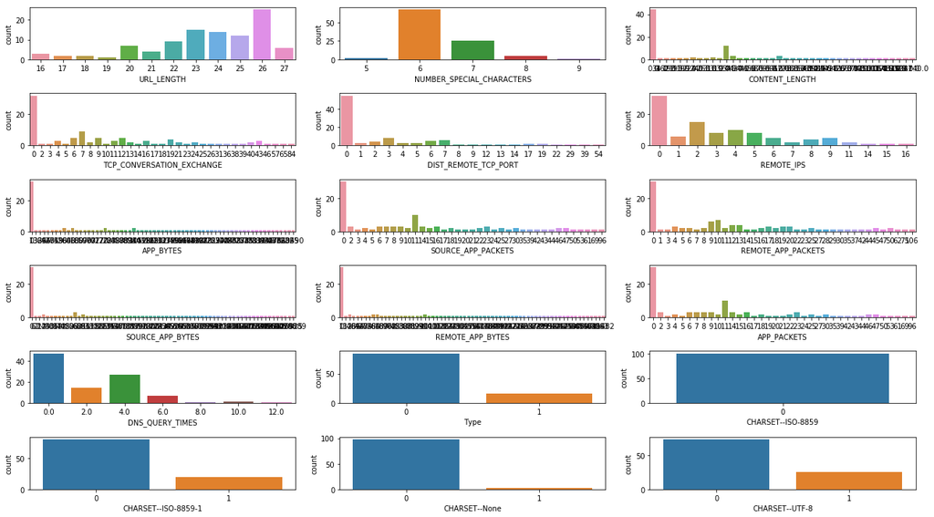

```python
fig, axs = plt.subplots(nrows=6, ncols=3)
fig.set_size_inches(18, 10)
axs = axs.flatten()
colnames = data.columns.tolist()[:100]

for ax, col in zip(axs, colnames):
    sns.countplot(x=col, data=data[:100], ax=ax)
plt.tight_layout()
```

**Some observations**

The above plot shows the number of the feature values vs its frequency (counts). As we observe from the above distribution plot there are enough information to extract from the data.

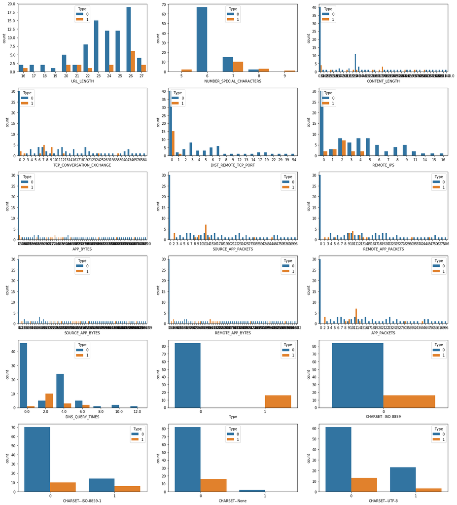

```python
fig, axs = plt.subplots(nrows=6, ncols=3)
fig.set_size_inches(18, 20)

axs = axs.flatten()

for col, ax in zip(data[:100], axs):
    sns.countplot(x=col, hue="Type", data=data[:100], ax=ax)

plt.tight_layout()
```

**Some observations**

The output classes are randomly distributed across the data distribution so there are no correlation observed from the data.

## Balance the data using SMOTE algorithm

This is an important step as the ML algorithms works better with a balanced data.

```python
X = data.drop(['Type'], axis=1)
y = data['Type']
```

```python
from imblearn.over_sampling import SMOTE

ros = SMOTE(random_state=42)
X_resampled, y_resampled = ros.fit_resample(X, y)
print(X_resampled.shape)
print(y_resampled)
```

```
(3130, 1978)
[1 0 0 ... 1 1 1]
```

```python
import collections
collections.Counter(y_resampled)
```

```
Counter({1: 1565, 0: 1565})
```

Now we have equal data category 1565 for malicious URLs and 1565 for benign.

next step is to split the data into train (70%) / test (30%)

```python
from sklearn.model_selection import train_test_split
X_train, X_test, y_train, y_test = train_test_split(X_resampled, y_resampled, test_size=0.3, random_state=42)
X_train_orig, X_test_orig, y_train_orig, y_test_orig = train_test_split(X, y, test_size=0.3, random_state=42)
print('X_train: ',X_train.shape,'X_test: ', X_test.shape)
print('y_train: ',y_train.shape,'y_test: ', y_test.shape)
print('X_train_orig: ',X_train_orig.shape,'X_test_orig: ', X_test_orig.shape)
print('y_train_orig: ',y_train_orig.shape,'y_test_orig: ', y_test_orig.shape)
```

```
X_train:  (2191, 1978) X_test:  (939, 1978)
y_train:  (2191,) y_test:  (939,)
X_train_orig:  (1246, 1978) X_test_orig:  (535, 1978)
y_train_orig:  (1246,) y_test_orig:  (535,)
```

### Helper functions

- print_score
  - takes the classifier and print the score.
  - if the data is imbalanced the score will contain only the recall metric.

```python
from sklearn.model_selection import cross_val_predict, cross_val_score
from sklearn.metrics import confusion_matrix,accuracy_score, recall_score

# Visualize our results
def print_score(classifier, imbalanced_data = False):
    if imbalanced_data == True:
        train_score = recall_score(y_train_orig,classifier.predict(X_train_orig))
        test_score = recall_score(y_test_orig,classifier.predict(X_test_orig))
        print("Imbalanced data:\n")
        print("Training results:\n")
        print('Recall Score: {0:.4f}\n'.format(train_score))
        print("Testing results:\n")
        print('Recall Score: {0:.4f}\n'.format(test_score))
        print('Confusion Matrix:\n{}\n'.format(confusion_matrix(y_test,classifier.predict(X_test))))
        return {'training Recall':train_score,'testing Recall':test_score}
    train_score = accuracy_score(y_train,classifier.predict(X_train))
    train_recall = recall_score(y_train,classifier.predict(X_train))
    test_score = accuracy_score(y_test,classifier.predict(X_test))
    test_recall = recall_score(y_test,classifier.predict(X_test))
    print("Balanced data:\n")
    print("Training results:\n")
    print('Accuracy Score: {0:.4f}\n'.format(train_score))
    print("Testing results:\n")
    print('Accuracy Score: {0:.4f}\n'.format(test_score))
    print('Confusion Matrix:\n{}\n'.format(confusion_matrix(y_test,classifier.predict(X_test))))
    return {'training Recall':train_recall,'training accuracy':train_score,'testing Recall':test_recall,'testing accuracy':test_score}
```

## Bench mark model

```python
results = {}
results_orig = {}
```

```python
# Imbalanced data
from sklearn.dummy import DummyClassifier
dc = DummyClassifier(random_state=42)
dc.fit(X_train_orig, y_train_orig)
y_pred = dc.predict(X_test_orig)
dc_score = print_score(dc, imbalanced_data=True)
results_orig['Dummy Classifier'] = dc_score
```

```
Imbalanced data:

Training results:

Recall Score: 0.1329

Testing results:

Recall Score: 0.1507

Confusion Matrix:
[[427  56]
 [393  63]]
```

```python
# Balanced data
from sklearn.dummy import DummyClassifier
dc = DummyClassifier(random_state=42)
dc.fit(X_train, y_train)
y_pred = dc.predict(X_test)
dc_score = print_score(dc)
results['Dummy Classifier'] = dc_score
```

```
Balanced data:

Training results:

Accuracy Score: 0.5039

Testing results:

Accuracy Score: 0.4569

Confusion Matrix:
[[216 267]
 [243 213]]
```

### Training using diffrent algorithms

## Imbalanced Data

```python
from sklearn.svm import SVC
svc = SVC(gamma='auto')
svc.fit(X_train_orig, y_train_orig)
y_pred_orig = svc.predict(X_test_orig)
svc_score_orig = print_score(svc, imbalanced_data=True)
results_orig['SVC'] = svc_score_orig
```

```
Imbalanced data:

Training results:

Recall Score: 0.9860

Testing results:

Recall Score: 0.3699

Confusion Matrix:
[[483   0]
 [213 243]]
```

```python
from sklearn.ensemble import RandomForestClassifier
rf = RandomForestClassifier(n_estimators=10, max_depth=50, criterion = 'entropy')
rf.fit(X_train_orig, y_train_orig)
y_pred = rf.predict(X_test_orig)
rf_score = print_score(rf, imbalanced_data=True)
results_orig['Random Forest'] = rf_score
```

```
Imbalanced data:

Training results:

Recall Score: 0.9441

Testing results:

Recall Score: 0.6712

Confusion Matrix:
[[482   1]
 [ 82 374]]
```

```python
from sklearn.tree import DecisionTreeClassifier
dtc = DecisionTreeClassifier()
dtc.fit(X_train_orig, y_train_orig)
y_pred = dtc.predict(X_test_orig)
dtc_score = print_score(dtc, imbalanced_data=True)
results_orig['Decision Tree'] = dtc_score
```

```
Imbalanced data:

Training results:

Recall Score: 1.0000

Testing results:

Recall Score: 0.7808

Confusion Matrix:
[[479   4]
 [ 32 424]]
```

## Balanced data

```python
from sklearn.svm import SVC
svc = SVC(gamma='auto')
svc.fit(X_train, y_train)
y_pred = dtc.predict(X_test)
svc_score = print_score(svc)
results['SVC'] = svc_score
```

```
Balanced data:

Training results:

Accuracy Score: 0.9991

Testing results:

Accuracy Score: 0.8871

Confusion Matrix:
[[482   1]
 [105 351]]
```

```python
from sklearn.ensemble import RandomForestClassifier
rf = RandomForestClassifier(n_estimators=10, max_depth=15, criterion = 'entropy')
rf.fit(X_train, y_train)
y_pred = rf.predict(X_test)
rf_score = print_score(rf)
results['Random Forest'] = rf_score
```

```
Balanced data:

Training results:

Accuracy Score: 0.9922

Testing results:

Accuracy Score: 0.9744

Confusion Matrix:
[[475   8]
 [ 16 440]]
```

```python
from sklearn.tree import DecisionTreeClassifier
dtc = DecisionTreeClassifier()
dtc.fit(X_train, y_train)
y_pred = dtc.predict(X_test)
dtc_score = print_score(dtc)
results['Decision Tree'] = dtc_score
```

```
Balanced data:

Training results:

Accuracy Score: 1.0000

Testing results:

Accuracy Score: 0.9766

Confusion Matrix:
[[467  16]
 [  6 450]]
```

## Imbalanced data

```python
results_orig_t = pd.DataFrame(results_orig).T
display(results_orig_t)
```

|  | testing Recall | training Recall |
| --- | --- | --- |
| Dummy Classifier | 0.150685 | 0.132867 |
| SVC | 0.369863 | 0.986014 |
| Random Forest | 0.671233 | 0.944056 |
| Decision Tree | 0.780822 | 1.000000 |

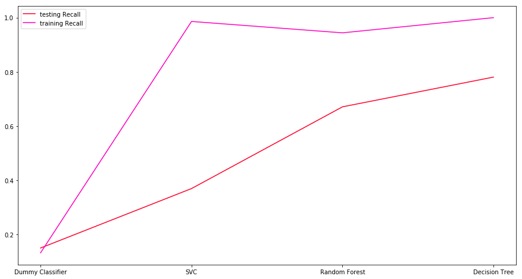

```python
rev_res = pd.DataFrame(results_orig).T.reset_index()
rev_res = rev_res.rename(columns={"index":"metric"})
ax = rev_res.plot(xticks=rev_res.index, figsize=(15,8), colormap='gist_rainbow')
ax.set_xticklabels(rev_res["metric"]);
```

## Balanced data

```python
results_t = pd.DataFrame(results).T
display(results_t)
```

|  | testing Recall | testing accuracy | training Recall | training accuracy |
| --- | --- | --- | --- | --- |
| Dummy Classifier | 0.467105 | 0.456869 | 0.502254 | 0.503880 |
| SVC | 0.769737 | 0.887114 | 0.999098 | 0.999087 |
| Random Forest | 0.964912 | 0.974441 | 0.988278 | 0.992241 |
| Decision Tree | 0.986842 | 0.976571 | 1.000000 | 1.000000 |

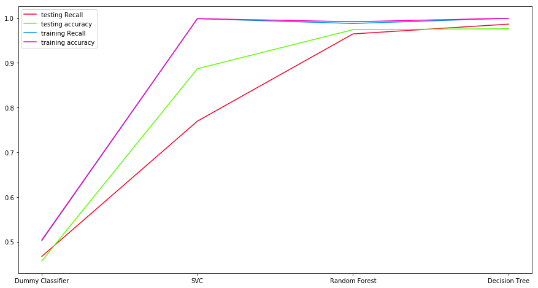

```python
rev_res = pd.DataFrame(results).T.reset_index()
rev_res = rev_res.rename(columns={"index":"metric"})
ax = rev_res.plot(xticks=rev_res.index, figsize=(15,8), colormap='gist_rainbow')
ax.set_xticklabels(rev_res["metric"]);
```

## Improvements

improve the best fit algorithm using grid search technique to find out the best parameters

```python
from sklearn.model_selection import GridSearchCV
from sklearn.model_selection import cross_val_score

parameters = {'criterion': ['gini', 'entropy'],'max_depth': [2,5,10,15,None]}

sg = GridSearchCV(dtc, param_grid=parameters, scoring='recall', cv=10)
grid_fit = sg.fit(X_train, y_train)
best_clf = grid_fit.best_estimator_
best_predictions = best_clf.predict(X_test)
```

```python
print(sg.best_params_)
tuned_scores = cross_val_score(best_clf, X_train, y_train, cv=10, scoring='recall')
```

```
{'criterion': 'entropy', 'max_depth': 15}
```

```python
# default and optimized models accuracies
print("Decision Tree Classifier Results:\n")
print("Unoptimized Model Testing Recall: {:.4f}".format(results['Decision Tree']['testing Recall']))
print("Unoptimized Model Testing Accuracy: {:.4f}".format(results['Decision Tree']['testing accuracy']))

print("Optimized Model Testing Recall: {:.4f}".format(recall_score(y_test, best_predictions)))
print("Optimized Model Testing Accuracy: {:.4f}".format(accuracy_score(y_test, best_predictions)))
print("Optimized Model Cross Validation Score: {:.4f}\n".format(tuned_scores.mean()))
```

```
Decision Tree Classifier Results:

Unoptimized Model Testing Recall: 0.9868
Unoptimized Model Testing Accuracy: 0.9766
Optimized Model Testing Recall: 0.9868
Optimized Model Testing Accuracy: 0.9766
Optimized Model Cross Validation Score: 0.9748
```

### Output Visualizations:

Best classifier top feature importance.

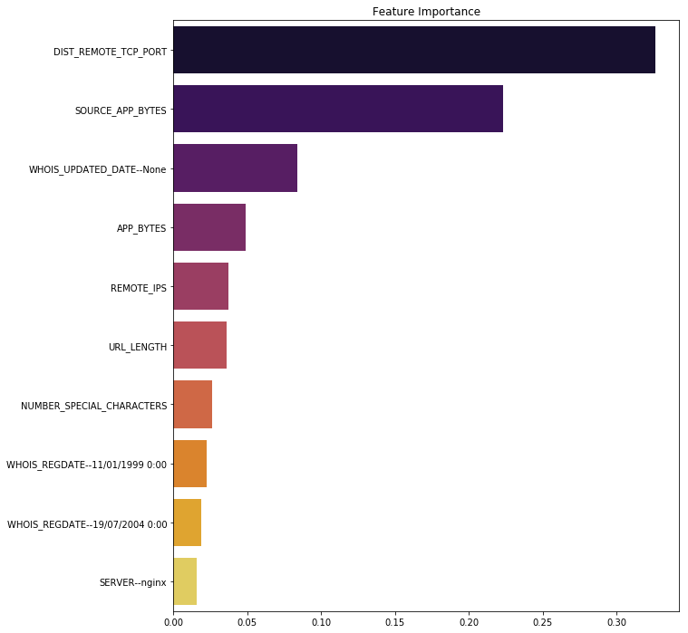

```python
plt.figure(figsize=(10,12))
plt.title("Feature Importance")
imp = pd.Series(data=best_clf.feature_importances_, index=X_train_orig.columns).sort_values(ascending=False)[:10]
ax = sns.barplot(y=imp.index, x=imp.values, palette="inferno", orient='h')
```